# Part I - (Bike Sales Dataset Exploration)

2D Plot versus Scatter plots

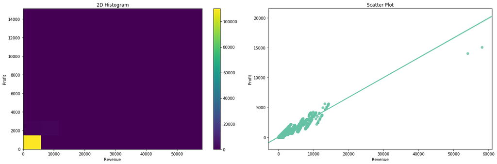

```python
import matplotlib.pyplot as plt

plt.figure(figsize=[18, 6])

# Subplot 1 - 2D Histogram
plt.subplot(1, 2, 1)
plt.hist2d(data=df_sales, x='Revenue', y='Profit')
plt.colorbar()
plt.xlabel('Revenue')
plt.ylabel('Profit')
plt.title('2D Histogram')

# Subplot 2 - Scatter Plot
plt.subplot(1, 2, 2)
sns.regplot(data= df_sales,x='Revenue', y= 'Profit')
plt.xlabel('Revenue')
plt.ylabel('Profit')
plt.title('Scatter Plot')

plt.tight_layout()  # Adjust the spacing between subplots
plt.show()
```

Heat map for Revenue and Profit

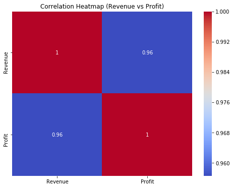

```python
# df_sales with "Revenue" and "Profit" columns

# Calculate the correlation matrix
correlation_matrix = df_sales[['Revenue', 'Profit']].corr()

# Create a heatmap of the correlation matrix
plt.figure(figsize=(8, 6))
sb.heatmap(correlation_matrix, annot=True, cmap='coolwarm')

plt.title('Correlation Heatmap (Revenue vs Profit)')
plt.show()
```

Relationship between Age and Revenue

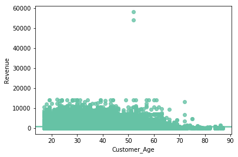

```python
sns.regplot(data= df_sales,x='Customer_Age', y= 'Revenue')
plt.show()
```

```python
#  df_sales with "Revenue" and "Profit" columns
correlation = df_sales['Customer_Age'].corr(df_sales['Revenue'])

print("Correlation coefficient between Customer_Age and Revenue:", correlation)
```

```
Correlation coefficient between Customer_Age and Revenue: -0.00932639702818
```

It shows a weak corelation between the Age of customer and the revenue.

```python
Quantitative_vars = ['Year', 'Customer_Age', 'Order_Quantity', 'Unit_Cost', 'Unit_Price', 'Profit', 'Cost', 'Revenue']
Qualitative_vars = ['Customer_Gender', 'Country', 'State', 'Product_Category', 'Sub_Category', 'Product']
```

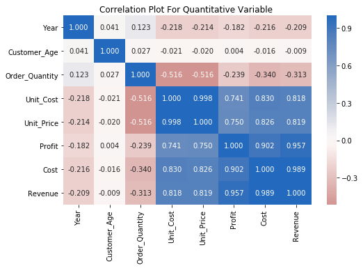

```python
# correlation plot
# Set the figure size
plt.figure(figsize=[8, 5])

# Create the heatmap
sb.heatmap(df_sales[Quantitative_vars].corr(), annot=True, fmt='.3f', cmap='vlag_r', center=0)


# Add title to the plot
plt.title('Correlation Plot For Quantitative Variable ')

# Display the plot
plt.show()
```

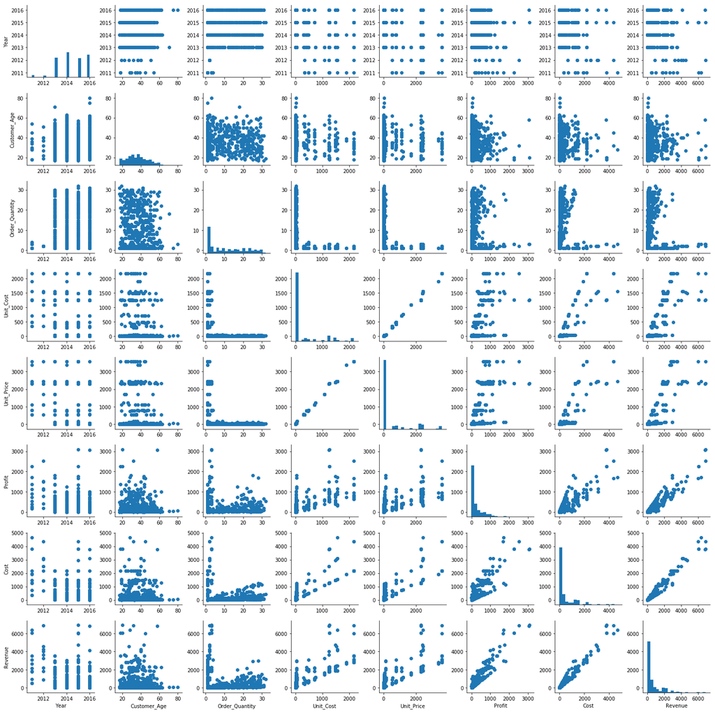

```python
# plot matrix: sample 500 diamonds so that plots are clearer and
# Sample 500 random rows from df_sales
samples = np.random.choice(df_sales.shape[0], 500, replace=False)
df_sales_samp = df_sales.loc[samples, :]

# Create PairGrid plot
g = sb.PairGrid(data=df_sales_samp, vars=Quantitative_vars)

# Plot histograms on diagonal subplots
g = g.map_diag(plt.hist, bins=20)

# Plot scatter plots on off-diagonal subplots
g.map_offdiag(plt.scatter)

# Display the plot
plt.show()
```

From the matrix plot we can see the relationshp between the different variables.

```python
#creating a boxgrid function
def boxgrid(x, y, **kwargs):
    """
    Function for creating box plots with seaborn's PairGrid.
    """
    default_color = sb.color_palette()[0]
    sb.boxplot(x, y, color=default_color)

def boxplot_grid(data, y_vars, x_vars):
    """
    Function to create a PairGrid plot with box plots.

    Args:
        data (df_sales)
        y_vars (list): List of variables to be plotted on the y-axis.
        x_vars (list): List of variables to be plotted on the x-axis.
    """
    plt.figure(figsize=[12, 8])
    g = sb.PairGrid(data=data, y_vars=y_vars, x_vars=x_vars,
                    size=4, aspect=1.5)
    g.map(boxgrid)
    plt.show()
```

```python
# Call the function to plot Revenue and Profit against Qualitative variables
#samples = np.random.choice(df_sales.shape[0], 2000, replace=False)
#df_sales_samp = df_sales.loc[samples, :]

#boxplot_grid(df_sales_samp, ['Revenue', 'Profit'], Qualitative_vars)
```

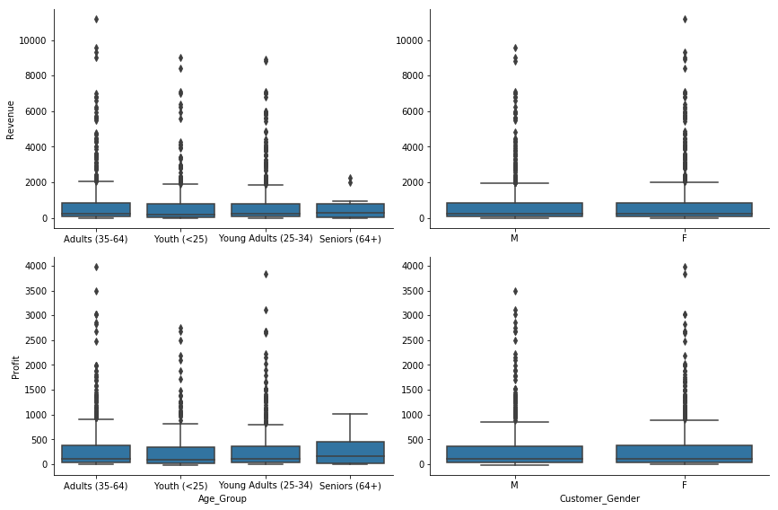

```python
# Call the function to plot Revenue and Profit against Categorical variables
categoric_vars_1 = ['Age_Group', 'Customer_Gender']
samples = np.random.choice(df_sales.shape[0], 2000, replace=False)
df_sales_samp = df_sales.loc[samples, :]

boxplot_grid(df_sales_samp, ['Revenue', 'Profit'], categoric_vars_1 )
```

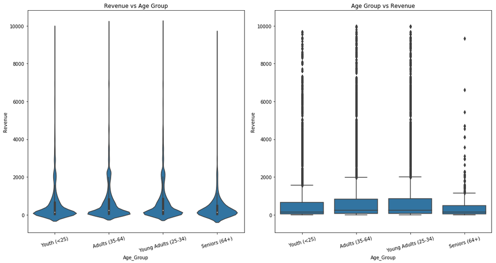

```python
df_sales_sub = df_sales[(df_sales['Revenue'] <= 10000)]
df_sales_sub = df_sales_sub[df_sales_sub['Age_Group'] != 'not Young Adults (25-34)']  # Corrected condition

plt.figure(figsize=[15, 8])
base_color = sb.color_palette()[0]

# Left plot: violin plot
plt.subplot(1, 2, 1)
ax1 = sb.violinplot(data=df_sales_sub, x='Age_Group', y='Revenue', color=base_color)
plt.xticks(rotation=15)
plt.title('Revenue vs Age Group')

# Right plot: box plot
plt.subplot(1, 2, 2)
sb.boxplot(data=df_sales_sub, x='Age_Group', y='Revenue', color=base_color)
plt.ylim(ax1.get_ylim())  # Set y-axis limits to be the same as the left plot
plt.xticks(rotation=15)
plt.title('Age Group vs Revenue')

plt.tight_layout()  # Adjust the spacing between subplots

plt.show()
```

Customer with in Age group seniors (64+) has less revenue

Time series of profit by year

```python
df_filtered = df_sales[(df_sales['Year'] >= 2011) & (df_sales['Year'] <= 2016)]
```

```python
profit_by_year = df_filtered.groupby('Year')['Profit'].sum()
```

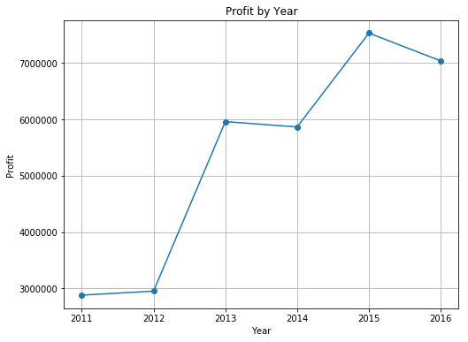

```python
Year = profit_by_year.index
Profit = profit_by_year.values

# Create a figure with size 8x6
plt.figure(figsize=(8, 6))

# Plot the profit by year
plt.plot(Year, Profit, marker='o', linestyle='-')

# Set the title, x-label, and y-label
plt.title('Profit by Year')
plt.xlabel('Year')
plt.ylabel('Profit')

# Add a grid
plt.grid(True)

# Display the plot
plt.show()
```

```python
df_filtered = df_sales[(df_sales['Year'] >= 2011) & (df_sales['Year'] <= 2016)]
```

```python
profit_by_year_gender = df_filtered.groupby(['Year', 'Customer_Gender'])['Profit'].sum()
```

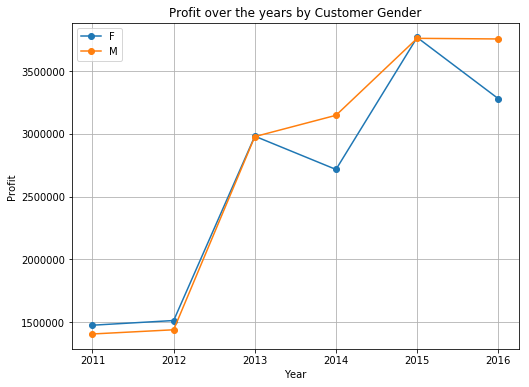

```python
years = profit_by_year_gender.index.levels[0]
genders = profit_by_year_gender.index.levels[1]

# Create a figure with size 8x6
plt.figure(figsize=(8, 6))

# Loop over each gender
for gender in genders:
    profits = profit_by_year_gender.loc[:, gender]
    # Plot the profits for each year
    plt.plot(years, profits, marker='o', linestyle='-', label=gender)

# Set the title, x-label, and y-label
plt.title('Profit over the years by Customer Gender')
plt.xlabel('Year')
plt.ylabel('Profit')

# Add a legend, grid, and display the plot
plt.legend()
plt.grid(True)
plt.show()
```

### Talk about some of the relationships you observed in this part of the investigation. How did the feature(s) of interest vary with other features in the dataset?

> Customer age, year, and order Quantiry happens to have a weak corelation with reveneue. However, cost, Unit Price, and revenue have positive relationsips

### Did you observe any interesting relationships between the other features (not the main feature(s) of interest)?

> There was a weak corellation between Age of Customer and Revenue. Profit started decreasing for female customers after 2015.

## Multivariate Exploration

> Create plots of three or more variables to investigate your data even further. Make sure that your investigations are justified, and follow from your work in the previous sections.

Profit across Age group and Customer gender

```
Text(0.5,1,'Sales Profit across Age_Group and Customer_Gender')
```

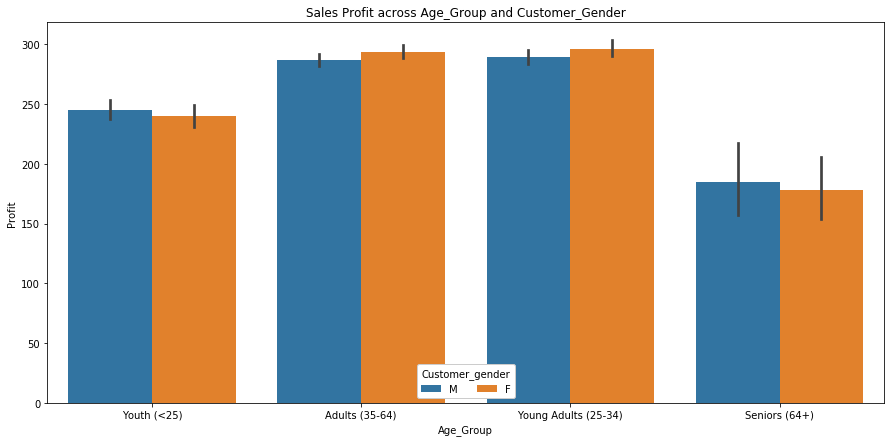

```python
plt.figure(figsize=[15, 7])

# Generate the bar chart
ax = sb.barplot(data=df_sales_sub, x='Age_Group', y='Profit', hue='Customer_Gender')

# Customize the legend
ax.legend(loc=8, ncol=3, framealpha=1, title='Customer_gender')

# Set the chart title
plt.title('Sales Profit across Age_Group and Customer_Gender')
```

From the previous analysis we concluded that Male customers brings more profit.However, from the above we can see that Female customers in Adult (35-64) and young Adults (25-34) categories bring in more profit sales

```
Text(0.5,1,'Profit Made from Customer Product Category and According to Their Gender')
```

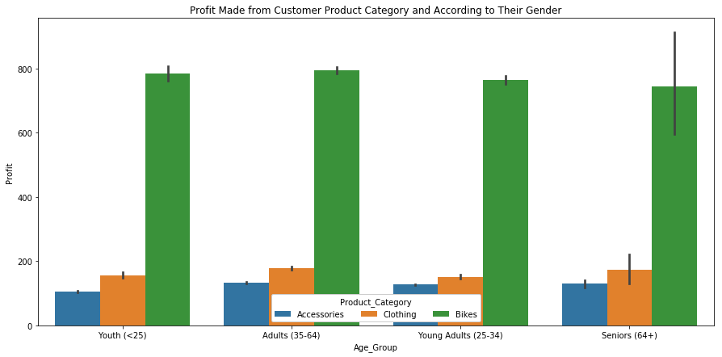

```python
plt.figure(figsize=[15, 7])

# Generate the bar chart
ax = sb.barplot(data=df_sales_sub, x='Age_Group', y='Profit', hue='Product_Category')

# Customize the legend
ax.legend(loc=8, ncol=3, framealpha=1, title='Product_Category')

# Set the chart title
plt.title('Profit Made from Customer Product Category and According to Their Gender')
```

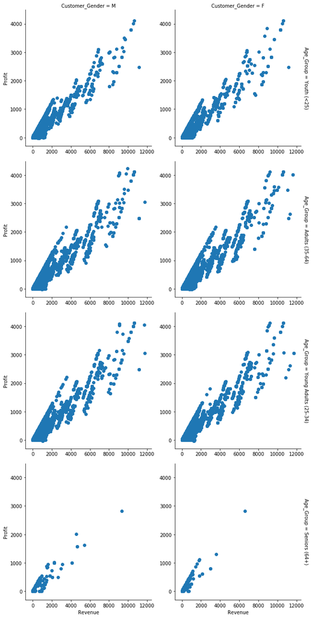

```python
# Create a FacetGrid plot
g = sb.FacetGrid(data = df_sales_sub, col = 'Customer_Gender', row = 'Age_Group', size = 4.5,
                margin_titles = True)
# Map scatter plot to each subplot
g.map(plt.scatter, 'Revenue', 'Profit');
```

From the above Facet plot, we can see that there is a strong relationship between profit and revenue in each subplot for Male and Female customers. But for Age group (seniors (64+), we can see a gap in the relationship and sudden decline as well. This could mean that because of their age they are no longer buying Bike or any other accessories.

Revenue made from customers across Age group and Gender

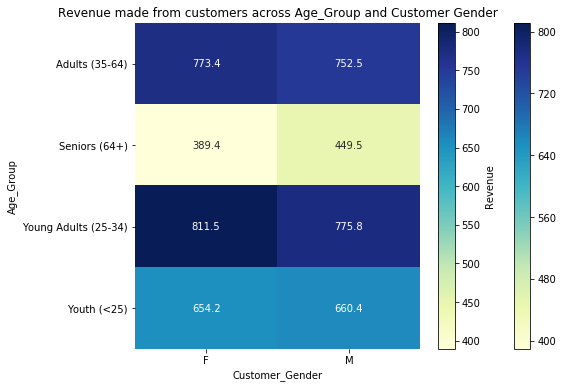

```python
# A matrix plot for quantitative variable (Year) based on the two categorical variables (Age_Group and Customer_gender)
heatmap_data = df_sales.pivot_table(values='Revenue', index='Age_Group', columns='Customer_Gender')

# Plot the heatmap
plt.figure(figsize=(8, 6))
heatmap = sns.heatmap(data=heatmap_data, cmap='YlGnBu', annot=True, fmt='.1f')
plt.title('Revenue made from customers across Age_Group and Customer Gender')
plt.xlabel('Customer_Gender')
plt.ylabel('Age_Group')

# Add colorbar with label
cbar = plt.colorbar(heatmap.collections[0])
cbar.set_label('Revenue')

plt.show()
```

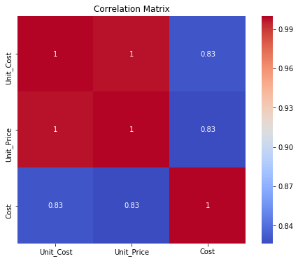

```python
# Calculate correlation matrix
correlation = df_sales[['Unit_Cost', 'Unit_Price', 'Cost']].corr()

# Create a figure and set the size
plt.figure(figsize=(8, 6))

# Create a heatmap with correlation values and annotations
sns.heatmap(correlation, annot=True, cmap='coolwarm', square=True)

# Set the title of the plot
plt.title('Correlation Matrix')

# Display the plot
plt.show()
```

The is strong corelation betwen Cost and Unit Cost

### Talk about some of the relationships you observed in this part of the investigation. How did the feature(s) of interest vary with other features in the dataset?

> It was interesting to see that even though male customers had more sales than Female counterpart. However, the Female customers in Adult (35-64) and young Adults (25-34) categories generated more sales. In all the Age categories, Bike had more profit.

### Did you observe any interesting relationships between the other features (not the main feature(s) of interest)?

> There is a positive relationship amongs Unit Cost, Unit price and Cost.

## Conclusions

> Inconclusion, It was interesting to see that even though moast sales were from Male customers but more sales came from Female customers in Adult (35-64) and young Adults (25-34) categories.We noticed thatn see that most sales where from United states and Califonia as a State. Also,customer was With Age 28 having to top the list of those who brought in more sales. Bike showed to be the most bought Sub_category.

## Reference

https://learn.udacity.com/nanodegrees/nd002/parts/cd0016/lessons/ls2239/concepts/6c40029a-47bd-4992-bb94-930dd4947bb2

https://learn.udacity.com/nanodegrees/nd002/parts/cd0016/lessons/ls2239/concepts/a8a820fc-aeba-4a35-b39b-af27874c1317

https://learn.udacity.com/nanodegrees/nd002/parts/cd0016/lessons/ls2239/concepts/0d45b011-9d5c-467f-9bd9-0ba1ed722e82

https://www.kaggle.com/datasets/sadiqshah/bike-sales-in-europe